# Analysis of Road Accidents to minimize future possibilities for Road mishaps

Chormi Zimik Vashai and Pavan Kumar Rudrapogu

4/14/2023

#### Github link to our project: https://github.com/Chormi/Finals_project_R.git

#### please read the Readme file in github to download the data

Michigan being the place of world’s leading producer of automobiles and weather conditions varying from snowing to windy to raining to clear skies, we are motivated to work on this project as the above factors will help audience understand the picture of road safety influence by machines and nature. Our project will target common people who commute daily on public transport of individual transport.

Travelling by Car is the least safe way to travel as compared to Flights, Boat, and Train. With our project we would like to learn, with our data, the reasons contributing to accidents. We would like to research the factors that play a key role and the factors that humans can control to reduce accidents. Our objective is to find study these data where number of factors such as time of accident, age of driver, road conditions etc are found.

To be begin we first load the necessary packages. If they aren’t installed yet, then you can simply install using the below code.

- Install and load required packages

```r
#tinytex::install_tinytex()
#install.packages("dplyr")
#install.packages("ggplot2")
#install.packages("RColorBrewer")
#install.packages("mice")
library("dplyr")
library("ggplot2")
library("RColorBrewer")
library("mice")
```

Our data is called freeway crashes.CSV. This is from https://www.michigantrafficcrashfacts.org/. Michigan State police share raw crashes with WMU Transportation Research Centre for Livable Communities. Our data contains all possible factors and details of recorded crashes. The data includes environmental factors, roadways, vehicle types, human factors, weather conditions etc. This will be important for us in analyzing accident data. Our data has 400,000 entries with 30 columns. BUt of course, we will be cleaning the data i.e. fix missing values or anomalies by imputing,deleting etc

```r
my_data <- read.csv("freeway crashes.CSV", stringsAsFactors = FALSE)
```

### Data cleansing/Wrangling:

Our data has some columns that aren’t required for analysis e.g Crash ID of the accident, Private ID given to the driver etc. Hence we have removed them in the first place.ALso the alcohol and Drug use column has been combined into one table using OR logic.

```r
#removing columns that aren't required
new_data<-my_data[-c(2:9,12,13,10,19,20,21,22,24,25,26)]

#joiining alc and drug use column into one column called alc_drug
new_data$alc_drug <- ifelse(new_data$alch_susp_ind | new_data$drug_susp_ind, 1, 0)

#deleting alc and drug column
new_data<-new_data[-c(9,10)]

View(new_data)
```

Looking at the data, we find that 2013 has missing “prty_age”, which is the age of the driver. TO decide whether to should omit 2013 data from our analysis or impute the data, we do the following analysis first.  
1a. Mean Imputation

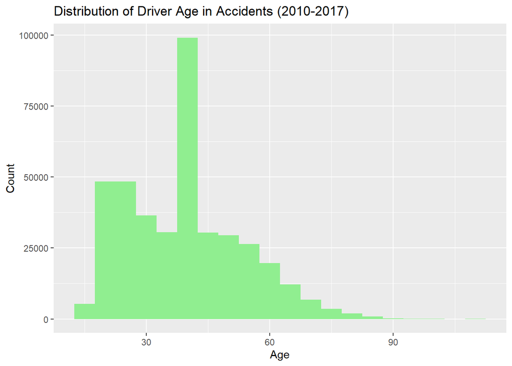

```r
mean_data<-new_data
mean_age <- mean(mean_data$prty_age, na.rm = TRUE)
mean_data$prty_age <- ifelse(is.na(mean_data$prty_age), mean_age, mean_data$prty_age)

ggplot(mean_data, aes(x = prty_age)) +
  geom_histogram(binwidth = 5, fill = "lightgreen") +
  labs(title = "Distribution of Driver Age in Accidents (2010-2017)",
       x = "Age",
       y = "Count")
```

```r
# Notice the huge count in age around 38 years, which is due to mean imputing. We won't be using this as this add only one fixed value to the missing values and dilutes the quality of our data.
```